# Linear Model

### Load dataset

For this model, we will use the following training and testing datasets:

- `prediction_dataset.csv`: For prediction purposes
- `regression_dataset.csv`: For training and regression purposes
- `vnm_.csv`: For constraints purposes

All data sets have been cleaned and contain no missing values.

```r
# Regression Dataset
regression_data <- read.csv(file.path(data_dir, "training_data/regression_dataset.csv"))

# Prediction Dataset
prediction_data <- read.csv(file.path(data_dir, "training_data/prediction_dataset.csv"))

# National GDP totals used to constrain the regression fit
constrained_data <- read.csv(file.path(data_dir, "_vnm_indicators/vnm_level0_gdp.csv"))

# Provincial GRDP per-capita targets used to calibrate 2025 level-2 predictions
provincial_grdp_data <- read.csv(file.path(data_dir,
  "_vnm_indicators/vnm_GRDPpc.csv"),
  check.names = FALSE
)

# Provincial population totals (thousands) used as the aggregation constraint
provincial_population_data <- read.csv(file.path(data_dir,
  "_vnm_indicators/vnm_population.csv"),
  check.names = FALSE
)

# Provincial population data are in thousands; convert to persons.
regression_data$population <- regression_data$population * 1000
provincial_population_data[, as.character(2020:2025)] <-
  provincial_population_data[, as.character(2020:2025)] * 1000
```

### Shared training and holdout setup

The shared setup converts regression population to persons, splits 2020–2024 from the 2025 holdout, standardizes the common features and outcome using training-only statistics, applies those transformations to both partitions, and computes linear temporal extrapolation weights. The native OLS reference predictions are saved for comparison; the constrained linear fit remains model-specific.

```r
model_setup <- prepare_model_comparison_setup(regression_data)
regression_data <- model_setup$regression_data
training_data <- model_setup$training_data
holdout_data <- model_setup$holdout_data
training_years <- model_setup$training_years
holdout_year <- model_setup$holdout_year
feature_columns <- model_setup$feature_columns
scaled_feature_columns <- model_setup$scaled_feature_columns
feature_means <- model_setup$feature_means
feature_sds <- model_setup$feature_sds
temporal_extrapolation_weights <- model_setup$temporal_extrapolation_weights

ols_comparison <- fit_ols_comparison(model_setup)
ols_reference_predictions <- ols_comparison$holdout
ols_reference_predictions$residual <-
  ols_reference_predictions$actual - ols_reference_predictions$predicted
ols_reference_predictions$residual_scaled <-
  ols_reference_predictions$actual_scaled -
  ols_reference_predictions$predicted_scaled
```

### Preliminaries

Supposed:

- $y \in \mathbb{R}^n$: observed outcome vector. That is, `grdp_per_capita`.
- $x_i \in \mathbb{R}^3$: standardized explanatory variables for observation $i$: `mean_radiance`, `population`, and `pixel_count`.
- $\alpha_t \in \mathbb{R}$: year-specific intercept for year $t$.
- $\beta \in \mathbb{R}^3$: shared slopes for the explanatory variables.
- $a_t \in \mathbb{R}$: specified national GDP total for year $t$.

The model includes a separate training-year intercept and shared slopes for the explanatory variables. It is fit on standardized 2020–2024 data only; the population-weighted national GDP constraints apply to those training years. The 2025 holdout is scored against the shared OLS baseline without refitting.

This chunk binds the common training and holdout design matrices and outcomes to the constrained model’s symbols. It also matches national GDP targets to training years; the subsequent equality constraints use population-weighted predicted per-capita values to reproduce each matched annual total.

```r
# Constrained fitting uses exactly the shared training partition and design.
X <- model_setup$X_train
X_test <- model_setup$X_test
y_train_scaled <- model_setup$y_train
y <- model_setup$y_train_raw
y_test <- model_setup$y_test_raw
training_population <- training_data$population
year <- training_data$year
years <- training_years
population <- training_population
p <- ncol(X)
target_gdp <- constrained_data$gdp[
  match(training_years, constrained_data$year)
]
```

### Optimization problem

Fit only the 2020–2024 training data using the shared standardized response and design matrix. National GDP constraints are retained for these training years only; 2025 remains an untouched evaluation partition.
$$\boxed{
\begin{aligned}
\min_{\alpha,\beta}\quad & \|y_{\mathrm{train}}-\hat
y_{\mathrm{train}}\|_2^2\\
\text{s.t.}\quad
&\sum_{i:\,\mathrm{year}_i=t} P_i(\bar y+s_y\hat y_i)=a_t,
\quad t\in\{2020,\ldots,2024\},\\
&\hat y_i=\alpha_{\mathrm{year}_i}+x_i^\top\beta
\end{aligned}
}$$
In this implementation, the optimization variable spans the year-effect and standardized-feature columns in the common design matrix. The equality constraints convert standardized fitted values back to original units before applying population weights. CLARABEL solves this convex quadratic problem; an unsuccessful solver status stops execution rather than producing a partial fit.

```r
# Define optimization variable
beta <- Variable(p)

# Define standardized fitted values and convert them to GRDP-per-capita units.
y_hat_scaled <- X %*% beta
y_hat <- model_setup$response_mean +
  model_setup$response_sd * y_hat_scaled

# Define the annual GDP constraints for training years only.
constraints <- lapply(seq_along(years), function(i) {
  idx <- which(year == years[i])
  sum_entries(population[idx] * y_hat[idx]) / target_gdp[i] == 1
})

# Define constrained least-squares problem
problem <- Problem(
  Minimize(sum_squares(y_train_scaled - y_hat_scaled)),
  constraints
)

# Solve
result <- solve(problem, solver = "CLARABEL")
```

[output not shown]

```r
# Print results
print(result$status)
```

```
## [1] "optimal"
```

```r
if (result$status %in% c("optimal", "optimal_inaccurate")) {
  beta_hat <- value(beta)
  predictions <- as.vector(X %*% beta_hat) *
    model_setup$response_sd + model_setup$response_mean
  holdout_predictions <- as.vector(X_test %*% beta_hat) *
    model_setup$response_sd + model_setup$response_mean
  ols_predictions <- ols_comparison$training$predicted
  ols_holdout_predictions <- ols_comparison$holdout$predicted

  # Optimality and Constraints check
  yearly_check <- data.frame(
    year = years,
    predicted_total_grdp = sapply(years, function(t) {
      idx <- which(year == t)
      sum(population[idx] * predictions[idx])
    }),
    target_total_grdp = target_gdp
  )

  yearly_check$difference <-
    yearly_check$predicted_total_grdp -
    yearly_check$target_total_grdp

  print(beta_hat)
  print(yearly_check)
  print(result$value)

  # Save fitted model
  fitted_model <- list(
    coefficients = beta_hat,
    variable_names = colnames(X),
    years = training_years,
    response_mean = model_setup$response_mean,
    response_sd = model_setup$response_sd,
    solver = "CLARABEL",
    solver_status = result$status,
    objective_value = result$value
  )

  model_path = file.path(model_output_dir, "constrained_linear_model.rds")
  saveRDS(fitted_model, model_path)
  print(paste("Model saved to:", model_path))

} else {
  stop(sprintf("Constrained regression failed with solver status: %s", result$status))
}
```

```
##             [,1]
## [1,] -0.33947287
## [2,] -0.25971230
## [3,]  0.01205176
## [4,]  0.16500574
## [5,]  0.43299668
## [6,]  0.12939667
## [7,]  0.45931806
## [8,] -0.20368414
##   year predicted_total_grdp target_total_grdp    difference
## 1 2020           8044385730        8044385730  4.863739e-05
## 2 2021           8487475600        8487475600  6.580353e-05
## 3 2022           9621371820        9621371820  1.525879e-05
## 4 2023          10319058870       10319058870 -2.479553e-05
## 5 2024          11510328920       11510328920 -1.125336e-04
## [1] 91.85103
## [1] "Model saved to: /Users/kien0508/Sync/DA 401/SpatialGDP/code/R/model/linear_model/constrained_linear_model.rds"
```

### Statistical Summary

For each split, the response mean and total sum of squares are computed over that split’s observed GRDP-per-capita values. The reported comparison table contains training-fit diagnostics and the 2025 holdout scores for both the constrained model and the shared OLS reference.
$$\bar y = \frac{1}{n}\sum_{i=1}^{n} y_i,
\qquad
\mathrm{SST} = \sum_{i=1}^{n}(y_i-\bar y)^2.$$

The coefficient of determination is computed for each model as
$$R_C^2
= 1-\frac{\sum_{i=1}^{n}(y_i-\hat y_i^{(C)})^2}{\mathrm{SST}},
\qquad
R_{OLS}^2
= 1-\frac{\sum_{i=1}^{n}(y_i-\hat y_i^{(OLS)})^2}{\mathrm{SST}}.$$

The root mean squared error (RMSE), in GRDP-per-capita units, is
$$\mathrm{RMSE}_C
=\sqrt{\frac{1}{n}\sum_{i=1}^{n}(y_i-\hat y_i^{(C)})^2},
\qquad
\mathrm{RMSE}_{OLS}
=\sqrt{\frac{1}{n}\sum_{i=1}^{n}(y_i-\hat y_i^{(OLS)})^2}.$$

This chunk calculates residuals and delegates the training/holdout metric tables and diagnostic CSVs/figures to the shared helper. $R^2$ uses the observed outcome variation within each split, while RMSE is reported in original GRDP-per-capita units; OLS and constrained predictions are compared on identical rows.

```r
constrained_residuals <- y - predictions
ols_residuals <- y - ols_predictions
comparison_metrics <- write_model_comparison_diagnostics(
  model_name = "Constrained linear model",
  training_data = training_data,
  holdout_data = holdout_data,
  training_fitted = predictions,
  holdout_fitted = holdout_predictions,
  ols_training = ols_predictions,
  ols_holdout = ols_holdout_predictions,
  data_output_dir = data_output_dir,
  figure_output_dir = figure_output_dir,
  file_prefix = "linear_model",
  feature_columns = feature_columns
)
holdout_model_stats <- comparison_metrics[
  comparison_metrics$split == "holdout",
  c("model", "R_squared", "RMSE")
]
training_model_stats <- comparison_metrics[
  comparison_metrics$split == "training",
  c("model", "R_squared", "RMSE")
]
print(holdout_model_stats, row.names = FALSE)
```

```
##                             model R_squared     RMSE
##          Constrained linear model 0.3835293 35.65299
##  Ordinary least squares reference 0.3731519 35.95182
```

### Training fit and residual diagnostics

The next chunk records one row per training observation, including actual, constrained and OLS fitted values, residuals, year, and predictors. It derives standardized residuals and $\sqrt{|r_{\mathrm{std}}|}$ for scale-location diagnostics, then saves the table for reproducibility.

```r
# Training diagnostics data frame
training_diagnostics <- data.frame(
  province = training_data$province,
  year = year,
  actual = y,
  constrained_fitted = predictions,
  constrained_residual = constrained_residuals,
  ols_fitted = ols_predictions,
  ols_residual = ols_residuals,
  year_factor = factor(year),
  mean_radiance = training_data$mean_radiance,
  population = population,
  pixel_count = training_data$pixel_count
)

# Calculate standardized residuals
training_diagnostics <- training_diagnostics %>%
  mutate(
    standardized_residual = constrained_residual /
      sd(constrained_residual),
    scale_location = sqrt(abs(standardized_residual))
  )

# Save
write.csv(
  training_diagnostics,
  file.path(data_output_dir, "linear_model_training_fit_diagnostics.csv"),
  row.names = FALSE
)
```

This chunk plots observed training outcomes against constrained-model and OLS fitted values. The 45-degree line is the perfect-prediction reference; the figure is saved and embedded in the report.

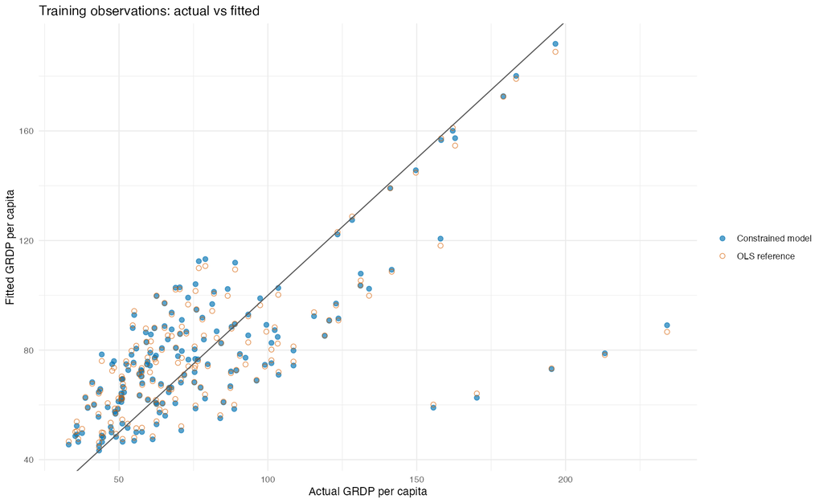

```r
# Fitted plot
actual_fitted_plot <- ggplot(training_diagnostics) +
  geom_point(
    aes(x = actual, y = constrained_fitted, color = "Constrained model"),
    size = 2, alpha = 0.65
  ) +
  geom_point(
    aes(x = actual, y = ols_fitted, color = "OLS reference"),
    shape = 1, size = 2, alpha = 0.65
  ) +
  geom_abline(
  aes(linetype = "Perfect fit"),
  slope = 1,
  intercept = 0,
  color = "gray35"
) +
  scale_color_manual(
    values = c(
      "Constrained model" = "#0072B2",
      "OLS reference" = "#D55E00"
    )
  ) +
  scale_linetype_manual(values = c("Perfect fit" = 2)) +
  coord_cartesian(
    xlim = range(training_diagnostics$actual),
    ylim = range(c(
      training_diagnostics$constrained_fitted,
      training_diagnostics$ols_fitted
    ))
  ) +
  labs(
    title = "Training observations: actual vs fitted",
    x = "Actual GRDP per capita",
    y = "Fitted GRDP per capita",
    color = NULL,
    linetype = NULL
  ) +
  theme_minimal()

# Save and display
actual_fitted_path <- file.path(
  figure_output_dir,
  "linear_model_training_actual_vs_fitted.png"
)
ggsave(
  actual_fitted_path,
  actual_fitted_plot,
  width = 11.25,
  height = 6.875,
  dpi = 160
)

knitr::include_graphics(actual_fitted_path)
```

The diagnostic panels examine residual patterns against fitted values and predictors, approximate normality, residual spread, and differences across years. These are visual checks rather than formal hypothesis tests. Because the constrained model imposes annual weighted-sum equalities, its residuals are not independent, identically distributed residuals assumed by standard OLS inference.

The following chunk builds those eight complementary plots: constrained and OLS residual-versus-fitted, a Q-Q plot, scale-location, residuals against each feature, and residual distributions by year. The population axis is shown on a log scale to make its wide range readable; these plots diagnose patterns but do not establish inferential assumptions.

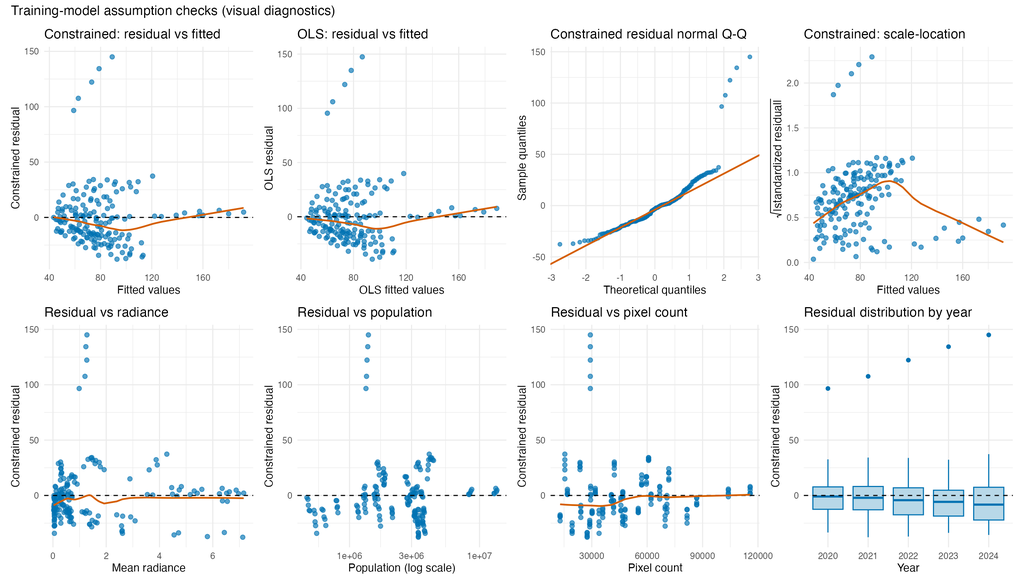

```r
# 1. Constrained: residual vs fitted
p1 <- residual_plot(
  training_diagnostics,
  "constrained_fitted", "constrained_residual",
  "Constrained: residual vs fitted",
  "Fitted values", "Constrained residual"
)

# 2. OLS: residual vs fitted
p2 <- residual_plot(
  training_diagnostics,
  "ols_fitted", "ols_residual",
  "OLS: residual vs fitted",
  "OLS fitted values", "OLS residual"
)

# 3. Normal Q-Q plot
p3 <- ggplot(
  training_diagnostics,
  aes(sample = constrained_residual)
) +
  stat_qq(
    color = "#0072B2",
    alpha = 0.65
  ) +
  stat_qq_line(
    color = "#D55E00",
    linewidth = 0.8
  ) +
  labs(
    title = "Constrained residual normal Q-Q",
    x = "Theoretical quantiles",
    y = "Sample quantiles"
  ) +
  theme_minimal()

# 4. Scale-location
p4 <- residual_plot(
  training_diagnostics,
  "constrained_fitted", "scale_location",
  "Constrained: scale-location",
  "Fitted values",
  expression(sqrt("|standardized residual|")),
  zero_line = FALSE
)

# 5. Residual vs radiance
p5 <- residual_plot(
  training_diagnostics,
  "mean_radiance", "constrained_residual",
  "Residual vs radiance",
  "Mean radiance", "Constrained residual"
)

# 6. Residual vs population
p6 <- residual_plot(
  training_diagnostics,
  "population", "constrained_residual",
  "Residual vs population",
  "Population (log scale)", "Constrained residual",
  log_x = TRUE,
  smooth = FALSE
)

# 7. Residual vs pixel count
p7 <- residual_plot(
  training_diagnostics,
  "pixel_count", "constrained_residual",
  "Residual vs pixel count",
  "Pixel count", "Constrained residual"
)

# 8. Residual distribution by year
p8 <- ggplot(
  training_diagnostics,
  aes(x = year_factor, y = constrained_residual)
) +
  geom_boxplot(
    fill = "#B8D8E8",
    color = "#0072B2"
  ) +
  geom_hline(yintercept = 0, linetype = 2) +
  labs(
    title = "Residual distribution by year",
    x = "Year",
    y = "Constrained residual"
  ) +
  theme_minimal()

# Combine diagnostic plots into a 2 x 4 layout
residual_diagnostics_plot <-
  (p1 | p2 | p3 | p4) /
  (p5 | p6 | p7 | p8) +
  plot_annotation(
    title = "Training-model assumption checks (visual diagnostics)"
  )

# Save and display
residual_diagnostics_path <- file.path(
  figure_output_dir,
  "linear_model_training_residual_diagnostics.png"
)

ggsave(
  residual_diagnostics_path,
  residual_diagnostics_plot,
  width = 14,
  height = 8,
  dpi = 200
)

knitr::include_graphics(normalizePath(residual_diagnostics_path))
```

### 2025 Level-2 Predictions

The first prediction chunk joins each level-2 unit to its provincial 2025 target and population, then standardizes predictors using the training means and standard deviations. This keeps inference-time feature units consistent with fitting; it does not recompute scales from prediction observations.

The model first predicts GRDP per capita for each level-2 unit using the 2025 intercept and the same means and standard deviations used to standardize the training data. Next, we adjust these predictions so that their population weighted total matches the province’s reported 2025 GRDP per capita multiplied by its total population. To do this, we add the same adjustment $\delta_j$ to every level-2 prediction within province $j$:

$$\tilde y_{ij} = \hat y_{ij} + \delta_j$$

The adjustment is calculated as:

$$\delta_j = \frac{g_jN_j-\sum_{i\in
j}P_{ij}\hat y_{ij}} {\sum_{i\in j}P_{ij}}$$

where $g_j$ is the province’s reported GRDP per capita, $N_j$ is its total population, and $P_{ij}$ is the population of level-2 unit $i$.

```r
# Prediction adjustment variables
prediction_data$grdp_pc_2025 <- provincial_grdp_data[["2025"]][
  match(prediction_data$level_1, provincial_grdp_data$province)
]

prediction_data$province_population_2025 <- provincial_population_data[["2025"]][
  match(prediction_data$level_1, provincial_population_data$province)
]

# Scale features with the shared training statistics.
for (feature in feature_columns) {
  prediction_data[[paste0(feature, "_scaled")]] <-
    (prediction_data[[feature]] - feature_means[[feature]]) /
    feature_sds[[feature]]
}

# Prediction features
prediction_features <- as.matrix(
  prediction_data[paste0(feature_columns, "_scaled")]
)
```

The final prediction chunk extrapolates year effects to 2025, applies the fitted coefficients, and adds a common provincial offset $\delta_j$ so $\sum_{i\in j}P_{ij}(\hat y_{ij}+\delta_j)=g_jN_j$. It verifies the aggregation equality, then writes unit-level predictions and constraint checks. The offset is population-weighted because every unit in a province receives the same adjustment.

```r
# Extrapolate the fitted year effects to 2025, matching the shared holdout setup.
prediction_X <- cbind(
  matrix(
    rep(temporal_extrapolation_weights, each = nrow(prediction_data)),
    nrow = nrow(prediction_data)
  ),
  as.matrix(prediction_data[paste0(feature_columns, "_scaled")])
)
colnames(prediction_X) <- colnames(model_setup$X_train)

raw_predictions <- as.vector(prediction_X %*% beta_hat) *
  model_setup$response_sd + model_setup$response_mean


# Calculate a common adjustment for each province
province_names <- sort(unique(prediction_data$level_1))

province_adjustments <- setNames(
  numeric(length(province_names)),
  province_names
)

for (province in province_names) {

  # Identify level-2 units within the province
  idx <- which(prediction_data$level_1 == province)

  # Calculate total provincial population from level-2 units
  province_population <- sum(prediction_data$population[idx])

  # Calculate the target provincial GRDP
  target_total <- prediction_data$grdp_pc_2025[idx[1]] *
    province_population

  # Calculate the initial predicted provincial GRDP
  raw_total <- sum(
    prediction_data$population[idx] * raw_predictions[idx]
  )

  # Calculate the common adjustment for all level-2 units
  province_adjustments[province] <-
    (target_total - raw_total) / province_population
}


# Apply provincial adjustments to level-2 predictions
prediction_data$raw_grdp_per_capita <- raw_predictions

prediction_data$province_adjustment <-
  province_adjustments[prediction_data$level_1]

prediction_data$predicted_grdp_per_capita <-
  prediction_data$raw_grdp_per_capita +
  prediction_data$province_adjustment


# Verify provincial calibration
province_check <- do.call(rbind, lapply(
  province_names,
  function(province) {

    # Identify level-2 units within the province
    idx <- which(prediction_data$level_1 == province)

    # Calculate provincial population from level-2 units
    province_population <- sum(prediction_data$population[idx])

    # Retrieve the reported provincial GRDP per capita
    target_grdp_per_capita <- prediction_data$grdp_pc_2025[idx[1]]

    # Calculate target and predicted provincial GRDP
    target_total <- target_grdp_per_capita * province_population

    predicted_total <- sum(
      prediction_data$population[idx] *
        prediction_data$predicted_grdp_per_capita[idx]
    )

    data.frame(
      province = province,
      population = province_population,
      target_grdp_per_capita = target_grdp_per_capita,
      predicted_grdp_per_capita = predicted_total / province_population,
      target_total_grdp = target_total,
      predicted_total_grdp = predicted_total,
      difference = predicted_total - target_total
    )
  }
))


# Prepare level-2 prediction results
level2_predictions <- data.frame(
  level_2 = prediction_data$name,
  level_1 = prediction_data$level_1,
  year = prediction_data$year,
  population = prediction_data$population,
  raw_grdp_per_capita = prediction_data$raw_grdp_per_capita,
  province_adjustment = prediction_data$province_adjustment,
  predicted_grdp_per_capita = prediction_data$predicted_grdp_per_capita,
  province_grdp_per_capita_target_2025 = prediction_data$grdp_pc_2025
)


# Save prediction results
prediction_output <- file.path(
  data_output_dir,
  "linear_model_level2_predictions.csv"
)

write.csv(
  level2_predictions,
  prediction_output,
  row.names = FALSE
)


# Display results
print(province_check, row.names = FALSE)
```

```
##          province population target_grdp_per_capita predicted_grdp_per_capita
##          An Giang    4995214                   80.2                      80.2
##          Bac Ninh    2059480                  146.2                     146.2
##            Ca Mau    1988464                   78.6                      78.6
##           Can Tho    4112487                   94.9                      94.9
##          Cao Bang     573119                   49.6                      49.6
##           Da Nang    3122915                  110.6                     110.6
##           Dak Lak    3346853                   80.6                      80.6
##         Dien Bien     673091                   53.4                      53.4
##          Dong Nai    4491408                  150.8                     150.8
##         Dong Thap    4370046                   84.0                      84.0
##           Gia Lai    3583691                   85.0                      85.0
##            Ha Noi    8807523                  179.3                     179.3
##           Ha Tinh    1623061                   90.5                      90.5
##         Hai Phong    4664124                  177.0                     177.0
##  Ho Chi Minh city   14668098                  215.3                     215.3
##               Hue    1432986                   75.3                      75.3
##          Hung Yen    3567943                   98.9                      98.9
##         Khanh Hoa    2243553                  110.3                     110.3
##          Lai Chau     512601                   79.4                      79.4
##          Lam Dong    3872999                  105.2                     105.2
##          Lang Son     881384                   70.9                      70.9
##           Lao Cai    1770645                   84.7                      84.7
##           Nghe An    3831694                   67.6                      67.6
##         Ninh Binh    4412264                   89.2                      89.2
##           Phu Tho    4022493                  111.3                     111.3
##        Quang Ngai    2161735                  101.9                     101.9
##        Quang Ninh    1497447                  261.2                     261.2
##         Quang Tri    1870844                   77.4                      77.4
##            Son La    1404587                   71.4                      71.4
##          Tay Ninh    3254170                  115.6                     115.6
##       Thai Nguyen    1799489                  112.4                     112.4
##         Thanh Hoa    4320947                   88.5                      88.5
##       Tuyen Quang    1858056                   54.6                      54.6
##         Vinh Long    4257581                   82.4                      82.4
##  target_total_grdp predicted_total_grdp    difference
##          400616163            400616163  5.960464e-07
##          301095976            301095976 -5.960464e-08
##          156293270            156293270 -8.940697e-08
##          390275016            390275016  1.192093e-07
```

[output cut: 15 more lines]

```
##          407439495            407439495  1.788139e-07
##           62490126             62490126  0.000000e+00
##          149973632            149973632  0.000000e+00
##          259022514            259022514 -1.192093e-07
##          393573949            393573949 -7.748604e-07
##          447703471            447703471 -2.384186e-07
##          220280796            220280797  2.980232e-08
##          391133156            391133156 -5.960464e-08
##          144803326            144803326  2.980232e-08
##          100287512            100287512 -1.490116e-08
##          376182052            376182052 -1.788139e-07
##          202262564            202262564 -1.490116e-07
##          382403810            382403810  1.192093e-07
##          101449858            101449858  1.490116e-08
##          350824674            350824674  5.960464e-08
```

```r
head(level2_predictions)
```

```
##      level_2  level_1 year population raw_grdp_per_capita province_adjustment
## 1   Rạch Giá An Giang 2025     250661           132.52211           -15.97076
## 2   Phú Quốc An Giang 2025     157629            97.34898           -15.97076
## 3 Long Xuyên An Giang 2025     154858           117.66041           -15.97076
## 4   Châu Đốc An Giang 2025      97438           101.77430           -15.97076
## 5    Nhơn Mỹ An Giang 2025      89018            93.74433           -15.97076
## 6    Chợ Mới An Giang 2025      80832            94.63257           -15.97076
##   predicted_grdp_per_capita province_grdp_per_capita_target_2025
## 1                 116.55136                                 80.2
## 2                  81.37822                                 80.2
## 3                 101.68965                                 80.2
## 4                  85.80354                                 80.2
## 5                  77.77358                                 80.2
## 6                  78.66181                                 80.2
```